# Cascading extinctions as a hidden driver of insect decline - Kehoe - - Ecological Entomology - Wiley Online Library

[Ecological Entomology](https://onlinelibrary.wiley.com/journal/13652311)

[figure not shown]

Invited Review

Free Access

# Cascading extinctions as a hidden driver of insect decline

[Rachel Kehoe](https://onlinelibrary.wiley.com/action/doSearch?ContribAuthorStored=Kehoe%2C+Rachel)

[Enric Frago](https://onlinelibrary.wiley.com/action/doSearch?ContribAuthorStored=Frago%2C+Enric)

[Dirk Sanders](https://onlinelibrary.wiley.com/action/doSearch?ContribAuthorStored=Sanders%2C+Dirk)

Correspondence: Dirk Sanders, Centre for Ecology & Conservation, College of Life and Environmental Sciences, University of Exeter, Penryn, Cornwall TR10 9FE, U.K. Environment and Sustainability Institute, University of Exeter, Penryn, Cornwall TR10 9FE, U.K. E‐mail:

First published: 30 November 2020

https://doi.org/10.1111/een.12985

Associate Editor: Alex Córdoba‐Aguilar

## Abstract

1. The decline in insect abundance and diversity observed in many ecosystems is of major concern because of the long‐term consequences for ecosystem function and stability.

2. Species in ecological communities are connected through interactions forming complex networks. Therefore, initial extinctions can cause further species losses through co‐extinctions and extinction cascades, where single extinctions can lead to waves of secondary extinctions. Such knock‐on effects can multiply the initial impact of disturbances, thereby largely adding to the erosion of biodiversity. However, our knowledge of their importance for the current insect decline is hampered because secondary extinctions are challenging to both detect and predict.

3. In this review, we bring together theory and knowledge about secondary extinctions in the light of the main drivers of insect decline. We evaluate potential and evidence for cascading extinction for the different drivers and identify major pathways. By providing selected examples we discuss how habitat loss, pollution, species invasions, climate change and overexploitation can cause cascading extinctions. We argue that habitat loss and pollution in particular have the largest potential for such extinctions by changing community structure, the physical environment, and community robustness.

4. Overall, cascading extinction are part of an ecosystems' response to anthropogenic drivers but are so far not explicitly measured in their contribution when evaluating biodiversity loss. This knowledge is necessary to predict biodiversity loss and find strategies to buffer against the devastating long‐term impact of habitat loss, pollution, species invasions, and climate change.

## Introduction

Many studies report marked declines in insect abundance and diversity across ecosystems and taxa (Hallmann *et al*., 2017; Leather, 2018; Habel *et al*., 2019; Montgomery *et al*., 2020). However, while this negative trend holds for terrestrial insects, the authors of a recent meta‐analysis found much variation in the included datasets when observing different taxa and locations (van Klink *et al*., 2020). Overall, there is clear evidence that insects are declining and have done so for years in many habitats around the world, which is driven by changes in land‐use, pollution, biological interactions (mostly invasions), and climate change (Wilson & Fox, 2020.; Seibold *et al*., 2019; Sánchez‐Bayo & Wyckhuys, 2019; Cardoso *et al*., 2020; Wagner, 2020).

This overall negative trend for many insect populations has severe consequences for ecosystem stability and function (Soliveres *et al*., 2016; Fanin *et al*., 2018). First, there is a positive relationship between insect diversity and many of the functions they provide (e.g., Srivastava & Bell, 2009; Cardinale *et al*., 2012). Second, the interconnectedness of species in ecological communities allows an impact on single species to be transmitted to the rest of the community. Initial extinctions can therefore trigger further extinctions passed on through direct and indirect interactions that subsequently start a process destabilising whole ecological communities. Of particular concern are cascading extinctions, where this initial impact causes waves of species extinctions, thereby eroding biodiversity (Säterberg *et al*., 2013; Sanders *et al*., 2018a). This can lead to a reduction in functional redundancy (Sanders *et al*., 2018a; Biggs *et al*., 2020) and ultimately to an increased vulnerability to future disturbances.

In this review, we first discuss the theoretical background of secondary extinctions, which can be triggered by the loss or decline of resources, consumers, competitors, mutualists, or ecosystem engineers. We then explore the potential of such cascading extinction in the light of the main drivers of biodiversity decline by using selected examples from the literature. Ecological theory predicts that secondary or cascading extinctions are a threat responsible for many regional and local extinctions (Borrvall & Ebenman, 2006; Säterberg *et al*., 2013; Brodie *et al*., 2014). However, empirical evidence is hard to obtain because we still lack a more mechanistic understanding of how the initial disturbance is transmitted through interactions in ecological communities leading to secondary extinctions. Further it is often difficult to distinguish between cascading extinctions and background noise imposed by the constant environmental change caused by human activities. Therefore, even if theory (e.g., Thébault *et al*., 2007; Brodie *et al*., 2014) suggests that cascading extinctions are very important for our understanding of biodiversity loss, few experimental studies have explored this question (e.g., Donohue *et al*., 2017; Sanders *et al*., 2018a). In this paper, we argue that we still lack empirical knowledge to draw general conclusions, particularly studies of secondary extinctions that include whole community dynamics. Here we focus on insects, which are crucial parts of the wider community of different taxa, but a broader community approach is necessary to understand the role of cascading extinctions in driving their decline. We acknowledge the importance of considering insect links to other animal groups, and of experimental data coming from non‐insect groups to draw general conclusions on the mechanisms behind insect extinctions.

We bring together theory about the extinction cascades and current evidence of how major anthropogenic drivers lead to insect decline by presenting key examples and linking them to ecological mechanisms. This will help to evaluate the role of run‐away extinctions and find strategies to predict which ecological communities may be most at risk. Specifically, we first identify mechanisms for cascading extinctions and discuss pathways for the main drivers of insect decline to initiate such cascades. We then summarise the current evidence for cascades of secondary extinctions as hidden drivers for insect decline. Finally, we discuss the uncertainties and suggest ways for future research that can solve these uncertainties and increase our ability to predict the strength of extinction cascades, and when they are most likely to occur.

## Predicting secondary extinctions

In this section, we review basic theory about secondary extinctions with initial disturbances leading to varying consequences for community structure and stability; we apply this in the next section to the impact of drivers on insect populations. The magnitude of the follow‐on effects of the initial loss depends largely on the function or role of the species going extinct and the ability of the rest of the ecological community to compensate or buffer for that loss.

We can divide secondary extinctions into two main categories: follow‐on single extinction events (e.g., co‐extinctions), and cascading extinctions leading to further extinction events along the way as the impact is passed on to more and more species. Secondary extinctions can be triggered by the extinction of a species or a significant decline in abundance. The latter is potentially widespread because a species' role in a community depends on its population density. The function can be lost even when the species is still present, because it has declined below a certain threshold density: this impact is called ‘functional extinction’ (Säterberg *et al*., 2013; Sanders *et al*., 2018a). Many studies report a substantial decline in insect abundance and biomass with negative trends for many populations across the world (Hallmann *et al*., 2017; Seibold *et al*., 2019; Wagner, 2020), therefore, we can indeed expect this decline to be a major driver for secondary extinctions. Secondary extinctions are likely occurring at smaller landscape scales because at this scale populations interact more tightly with each other with significant consequences for ecosystem functions within local communities. However, declines and extinctions of local population also contribute to global extinctions and increase the overall extinction risk for species (Blaustein *et al*., 1994).

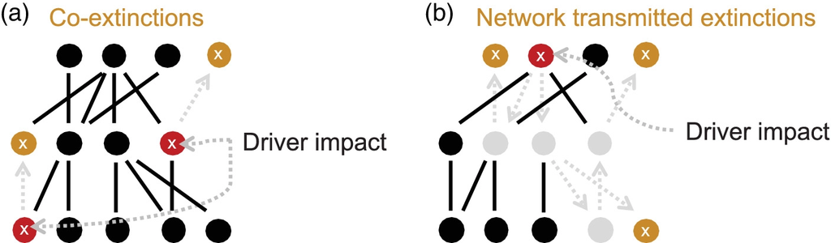

**Fig. 1**

Open in figure viewer[PowerPoint](https://onlinelibrary.wiley.com/action/downloadFigures?id=een12985-fig-0001&doi=10.1111%2Feen.12985)

Secondary extinctions. (a) Co‐extinctions after the initial loss of a resource, (b) network transmitted extinctions driven by changes in interaction strength and indirect interactions. Red nodes (with an x) in the food web are going initially extinct with the orange nodes as secondary extinctions. The arrows indicate the transmission of the initial impact. [Colour figure can be viewed at [wileyonlinelibrary.com](http://wileyonlinelibrary.com/)].

### *Co‐extinctions and network transmitted extinctions*

The majority of studies consider secondary extinctions to be co‐extinctions (Brodie *et al*., 2014; Veron *et al*., 2018; Cardoso *et al*., 2020): the direct dependence of one species on another leads to its demise, as for example when a parasite or a specialist predator goes extinct because their host or resource have disappeared (Fig. 1a). Co‐extinctions can involve many different types of interactions, such as pollination, seed dispersal, symbiosis, mutualism, parasitism, predation, and non‐trophic interactions and are most likely to affect resource or habitat specialists. For instance, a low population size of its hosts, the endangered black (*Diceros bicornis* (Linnaeus, 1758)) and white (*Ceratotherium simum* (Burchell, 1817) rhinoceroses, put the stomach bot fly *Gyrostigma rhinocerontis* (Owen, 1830) which is a specialist parasite (Colwell *et al*., 2009), in an even more endangered situation. We can expect the effect to be immediate for intimate interactions such as symbiosis or parasitism, or the absolute necessity of an ecosystem engineer such as a tree providing the habitat for an insect. As a possible common example of resource driven co‐extinctions, the extinction of butterflies on a tropical island in Singapore was a result of the loss of their host plants (Koh *et al*., 2004). The impact on the depending partner can be delayed in long‐lived species if the organism has the ability to survive on its own but relies on the extinct species for reproduction. For example, the extinction of larger vertebrates on islands poses a problem to seed dispersal and offspring recruitment for larger trees (Wang *et al*., 2007). A recent study done on Réunion island used lava chronosequences that spanned 300 years and revealed the strong impact of frugivore extinctions on forest community structure (Albert *et al*., 2020). The lower functional redundancy of island ecosystems substantially increases the risk of co‐extinctions (Kaiser‐Bunbury *et al*., 2010).

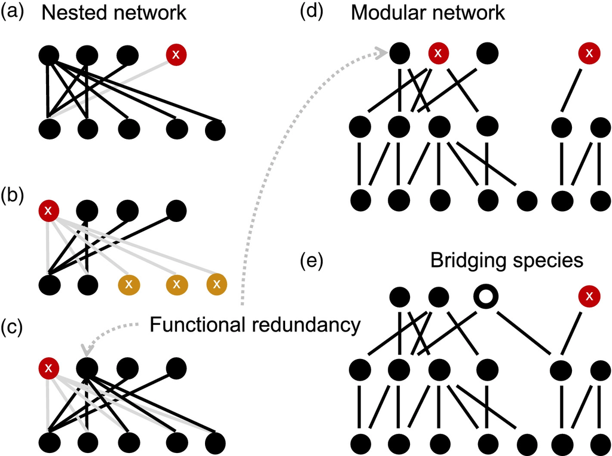

**Fig. 2**

Open in figure viewer[PowerPoint](https://onlinelibrary.wiley.com/action/downloadFigures?id=een12985-fig-0002&doi=10.1111%2Feen.12985)

Species in ecosystems form complex networks of interactions; this means the initial loss of a species can be transmitted along the interactions in networks and cause further extinctions, potentially to parts of the network found many links away (Fig. 1b). There is evidence that species that are targeted by harvesting are not the ones that go extinct in the first instance (Sanders *et al*., 2015). Concern should therefore be raised about the potential extinction of other indirectly connected species in the network. This impact can be transmitted through direct and indirect interactions. Indirect extinctions occur when the effect between two species is passed through at least a third one. From a large body of research in community ecology, we know of the importance of indirect interactions such as apparent competition, trophic cascades, apparent mutualism and higher order interactions for dynamics, stability, and functions (Wootton, 1994; Morris *et al*., 2004). Trophic cascades are a powerful example of indirect interactions, where diminished top‐down control leads to a marked negative impact on primary producers (Schmitz, 2003; Estes *et al*., 2011). The removal of otters through hunting, for instance, led to the release of sea urchins from top‐down control and the destruction of kelp forest, with a complete shift from diverse kelp forests to barren sea floor communities (Estes & Palmisano, 1974). The long, shared ecological and evolutionary histories of island tortoises and plant communities has shaped many plant‐tortoise interactions, many of which have since been lost as a result of tortoise decline or extinction (Sobral‐Souza *et al*., 2017). For example, ‘tortoise turf’ is a plant community of endemic grass, herb, and sedge species, which is engineered by continuous tortoise grazing and trampling. It is thought to have been common on islands throughout the Indian Ocean before tortoises went extinct; it is now restricted to Aldabra (Merton *et al*., 1976; Cheke & Hume, 2010). This demonstrates that predator or consumer extinctions can have far‐reaching consequences for whole ecosystems. Further, the loss of diversity or complexity in a community can indirectly lead to further extinctions through the loss of associational resistance. For example, the reduced diversity of non‐hosts in a community has been shown to increase parasitism of an insect host, leading to its overexploitation (Kehoe *et al*., 2016).

A bottom‐up extinction cascade is driven by the loss of a resource, which can be either food, habitat, or a condition that was provided by the presence or activity of another organism (e.g. a tree as a habitat for bats and many insects). In Yellowstone, the invasive lake trout *Salvelinus naymaycush* (Walbaum, 1792) reduced densities of the native cutthroat trout, *Oncorhynchus clarkii bouvieri* (Richardson), triggering large changes in aquatic arthropod communities which then triggered a bottom‐up effect on terrestrial communities of large predators including mammals and birds (Koel *et al*., 2005, 2020; Tronstad *et al*., 2010). This effect can likely cascade to insects as shown in Knight *et al*. (2005) who found that fish presence in ponds altered populations of aquatic insects and indirectly pollinators and pollination of terrestrial plants. The combined effect of top‐down and bottom‐up cascading effects can translate into horizontal extinction cascades as shown in (Sanders *et al*., 2015, 2018a). Predators can be necessary for the coexistence of lower trophic levels, for example, if predators regulate the density of the most competitive prey species. A predator extinction can thus lead to dominance shifts in prey and the extinctions of other predators that depend on them. Horizontal extinctions cascades are predicted to happen when consumer guilds are specialized to a certain degree, which means their function as predators is necessary. Research has shown that the system can be rescued by generalist predators providing functional redundancy and loosely linking different food web modules (Sanders *et al*., 2018a).

Most research on indirect extinctions has focused on effects driven by changes in the density of interacting species. Species declines, however, can also be transmitted via behavioural changes (also known as trait‐ mediated), but their impact on secondary extinctions is so far little studied. Trait‐mediated indirect effects are currently acknowledged as important in ecological communities (Peacor & Werner, 2001; Schmitz *et al*., 2004). For example, predator avoidance behaviours may allow species persistence by reducing the effectiveness of highly competitive competitors, a prediction that has been demonstrated by recent models showing that anti‐predator avoidance can allow community stability (Sommers & Chesson, 2019). Fear‐induced avoidance behaviour has been shown to promote species coexistence in many communities (Leibold, 1991; Werner, 1992). Research shows that fear of large carnivores reduces racoon activity and has a positive effect on racoon prey including insects (Suraci *et al*., 2016). Loss of these top predators can thus trigger extinction cascades through the loss of trait‐mediated indirect interactions, but more research is needed in more complex scenarios that for example combine different types of interactions in multilayer networks.

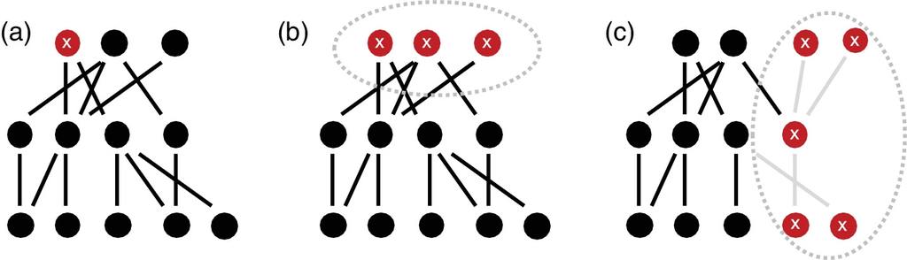

**Fig. 3**

Open in figure viewer[PowerPoint](https://onlinelibrary.wiley.com/action/downloadFigures?id=een12985-fig-0003&doi=10.1111%2Feen.12985)

Scale of the initial impact. An initial impact can lead to the loss of (a) single species, (b) functional groups or (c) parts of the network. [Colour figure can be viewed at [wileyonlinelibrary.com](http://wileyonlinelibrary.com/)].

### *The role of network structure in transmitting the effect of species extinctions*

The most insidious extinction cascades are those that erode the necessary structural network components for community stability (resistance, resilience, or robustness). Such a structural breakdown leaves the community vulnerable and is often associated with regime shifts and erosion of biodiversity (Hughes *et al*., 2007; Carpenter *et al*., 2011). For example, nestedness has been shown to increase robustness in mutualistic networks such as plant‐pollinator systems (Thébault & Fontaine, 2010). A nested network is characterised by a core of generalist species that link the whole network while any specialist is using only links that are already provided by generalists. This means the system is robust against specialist extinctions (Fig. 2a) but if a generalist from those communities is lost (Fig. 2b), this will have a marked effect on other species' persistence in the community (Bastolla *et al*., 2009; Thébault & Fontaine, 2010). Antagonistic networks such as food webs on the other hand gain increased stability through modularity (Fig. 2d, Thébault & Fontaine, 2010) where species interact in subnetworks that are not or only weakly linked. Theory predicts that this structural feature keeps a disturbance with a module rather than letting it spread through the whole network (Krause *et al*., 2003). Other studies, however, suggest that connectance (the proportion of realised links in a network) and functional redundancy (redundant links in a network, see Fig. 2c,d) are important structural components to buffer against secondary extinctions in antagonistic networks (Dunne *et al*., 2002; van Altena *et al*., 2016). Possibly there is truth in both: modules that are loosely linked by generalist predators (Fig. 2e) with a certain level of functional redundancy are likely to be most robust to cascades of secondary extinctions as shown in (Sanders *et al*., 2018a). This may explain the importance of generalist top predators, often called keystone predators, in maintaining stability because they prey on the most abundant prey and thereby enhance the survival of inferior competitors often allowing their coexistence within the community at different trophic levels (Paine, 1995). The loss of such a keystone predator can have far reaching consequences as an important structural component is lost (Estes *et al*., 2011). This means that as communities become simpler with biodiversity loss, networks become more vulnerable to cascading extinctions (Borrvall *et al*., 2000; Sanders *et al*., 2018a).

### *Scale of the initial impact*

To determine how important secondary extinctions are, and which ecological communities are more affected, we need knowledge on how often the initial disturbance hits and how different drivers of species extinctions interact. This initial impact can affect a single species (e.g., overexploitation) or the whole community (e.g., habitat loss) (Fig. 3a). It is difficult to predict which outcome is more likely to lead to more severe cascading extinctions because this very much depends on the role of the lost species. For example, predators might be more vulnerable than other trophic levels (Fig. 3b, Purvis *et al*., 2000) and if the coexistence at the lower trophic levels depends on top‐down control we can expect secondary extinctions after the loss of the predator guild. As discussed above, modularity increases robustness in food webs, so that the extinction of a whole sub‐network can potentially be contained within that part of the network with very little follow on extinction events. This, again, depends on the function of any bridging species to the remaining network. The loss of beavers and their dam building activity (Wright *et al*., 2002) will be most severe for the aquatic food web with weaker knock on‐effects on the terrestrial community (Fig. 3c). If the flow of energy into the terrestrial food web is substantial (as shown in the Yellowstone example above), however, this will lead to more important shifts in the community structure.

At the temporal level, in some instances the impact can be immediate, such as for many co‐extinctions. These are therefore easier to detect and predict from observational data. Network transmitted or functional extinction events will be much harder to uncover because they will be delayed through population dynamics and feedbacks (Sanders *et al*., 2015). Finally, if the disturbance has already led to irreversible changes in ecological communities, for example, by driving populations to a very low densities, or through the loss of mutualistic relationships, we can expect to see extinctions happening in the future, a phenomenon known as an extinction debt.

## Drivers of insect decline and cascading extinctions

Five main drivers have been made responsible for the decline in insect abundance and diversity (Habel *et al*., 2019; Sánchez‐Bayo & Wyckhuys, 2019; Cardoso *et al*., 2020; Fiza Fatima *et al*., 2020; Montgomery *et al*., 2020; van Klink *et al*., 2020; Wagner, 2020): (I) habitat loss and fragmentation associated with housing development and agriculture, timber, and livestock production, (II) pollution through spill of toxic chemicals into the environment and direct application of pesticides, as well as light and noise pollution: (III) invasive species, (IV) climate change and (V) overexploitation. There is a high degree of linkage between some of these drivers, with for example habitat loss driven itself by climate change. Additionally, individual drivers can interact with each other, with one increasing the severity of another. Climate change, for example, can alter the infection rate of Nosemosis in honeybee, *Apis mellifera* Linnaeus 1758 (Martín‐Hernández *et al*., 2009), while other factors such as pesticide load or decreased resource availability reduce the health of a population and leave the population more vulnerable to pests or pathogens (Potts *et al*., 2010). In order to understand, predict, and prevent insect losses from ecosystems, we need to identify the details of the pathways that lead to this loss. Here we look at the potential of cascading extinctions associated with each driver and their mechanisms and present a non‐exhaustive list of examples.

### *Habitat loss and degradation*

A recent review found that about 50% of articles researching insect decline, report habitat changes as the main driver (Sánchez‐Bayo & Wyckhuys, 2019). This highlights its importance in diminishing insect populations through the expansion and intensification of agriculture, forestry, livestock production, urbanisation, and mining (Brook *et al*., 2003; Habel *et al*., 2019; Mammola *et al*., 2019). This happened especially when agricultural practices shifted in many countries from traditional, low‐input farming style to intensive, industrial‐scale production (Bambaradeniya & Amerasinghe, 2004; Ollerton *et al*., 2014). Although habitat loss can directly kill insects when habitats are transformed, extinction events are likely to be caused by indirect effects such as the loss of resources and alteration of the physical environment.

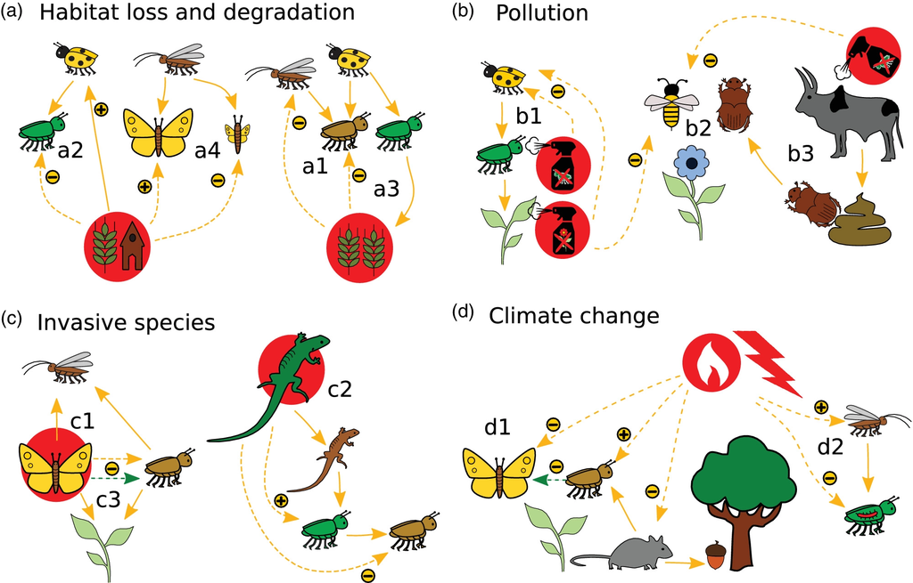

**Fig. 4**

Open in figure viewer[PowerPoint](https://onlinelibrary.wiley.com/action/downloadFigures?id=een12985-fig-0004&doi=10.1111%2Feen.12985)

Drivers and cascading extinctions. Arrows with continuous lines depict direct interactions. Indirect effects of drivers on insect extinctions are also shown as dashed lines. The initial impact through drivers is shown by a red circle. Higher‐trophic levels suffer from habitat loss as bottom‐up effects are magnified along food chains (a1). Habitat degradation can increase the density of insect natural enemies and trigger insect extinctions (a2). Highly fertilized agricultural habitats increase pest densities with negative indirect effect on other insects through apparent competition (a3). The impact of habitat loss depends on insect functional traits including dispersal capabilities, longevity and specialisation (a4). Pollution in the form of herbicides and insecticides bioaccumulates along food chains (b1). These products can kill non‐target organisms and trigger declines of pollinating insects thus altering plant‐pollinator networks and plant communities (b2). Anthelmintic substances used to treat worm infestation in livestock alter dung beetle communities (b3). Since some of these beetles are plant pollinators, this can also alter plant‐pollinator networks (b2). (c) Invasive species can trigger extinctions of local insects indirectly through shared natural enemies (i.e. apparent competition, c1), or by altering local plant communities and trigger bottom‐up extinction cascades (c3). Invasive predators can become top‐predators via intraguild predation and release certain populations of prey from top‐down pressure thus increasing pressure on others (c2). (d) Climate change alters the synchrony between plants and herbivores. Some omnivorous herbivores (here mice) also predate on insects thus controlling their populations. This equilibrium can be altered, and pest outbreaks triggered with negative effects on non‐pest species via resource competition (d1). Some insects rely on mutualistic symbioses (represented here as a red bacterium) to obtain protection from natural enemies. These symbionts are often susceptible to increased temperatures so that global warming can render these insects unprotected and susceptible to demise due to top‐down pressure (d2). [Colour figure can be viewed at [wileyonlinelibrary.com](http://wileyonlinelibrary.com/)].

Agriculture and deforestation substantially change natural plant communities, with those communities becoming homogenised and simplified, the removal of long‐lived plants, and the timing of flowering being changed (Thomas & Kevan, 1993). Agriculture often turns a natural environment into a habitat dominated by a select few plants, while urbanisation, intensive livestock production and mining can be even more extreme in removing the majority of plants from habitats. Both processes can lead to co‐extinctions of many plant‐associated insects. For example, the clearance of vegetation in Singapore caused the loss of 208 plant species upon which specialist butterfly species rely, with at least 56 butterfly species becoming co‐extinct (Koh *et al*., 2004). This has likely resulted in a cascade of extinctions as other species such as other herbivores and predators/parasitoids associated with these food web modules will have also lost their resources (Fig. 4a1). We can expect resource‐driven extinction cascades to be very common that affect many species. Vegetation structure is providing necessary habitat structure needed as shelter and refuge for many species while maintaining a specific microclimate. All plants are acting therefore essentially as ecosystem engineers (Jones *et al*., 1996; Sanders *et al*., 2014), with species and interactions between species depending on the state of this physical environment. In addition to providing a food resource, trees, for example, provide numerous abiotic requirements for insect survival such as both substrate for nests and webs (Santos & Gobbi, 1998). This includes plant fibre as an important material for nest building (Rodrigues & Machado, 1982), shading, and as such protection from direct sunlight and high temperatures, as well as desiccation, and camouflage against predators. Deforestation and logging remove these structures, which will indirectly cause the loss of species and change the strength of interactions between species (e.g., Chase, 1996). Declines in moths, for example, are linked to the availability of their overwintering host plants (Mattila *et al*., 2006; Fox, 2013), specialist ground beetles depend on hedgerows and trees (Brooks *et al*., 2012) and overall species diversity declines with decreasing vegetation complexity in many groups of organisms (Tews *et al*., 2004). Other ecosystem engineers can have a similarly marked role; with ants for example increasing grazing quality for cattle (Li *et al*., 2018), and shifting the balance of top‐down and bottom‐up effects (Zhong *et al*., 2017). The removal of ants, which are very sensitive to land use, can lead to reduced abundance of other insects and impact the diversity at higher trophic levels (Sanders & Veen, 2011).

Habitat change impacts the way species interact through the loss of refuges or by increasing the ability of predators to use the habitat or by limiting primary producer biomass; this can then lead to extinctions and important shifts in community structure. For example, urbanisation has been shown to promote the density of some avian predators (Evans *et al*., 2009) through the provision of nesting sites which can ultimately increase pressure and trigger top‐down extinctions of insect prey (Fig. 4a2). Urbanisation has also been shown to significantly change the way species interact by reducing the strength of a trophic cascade (Turrini *et al*., 2016). Uncovering these shifts needs well‐designed experiments, with the results then scaled up to the habitat level. Habitat loss can shift the balance between species that interact through apparent competition (Fig. 4a3). This may be common in temperate agricultural systems because they are often irrigated and fertilised, making them highly productive and therefore hosting large densities of insect pests (Garratt *et al*., 2011; Butler *et al*., 2012). These increased pest densities can lead to higher densities of generalist predators that can spill over to nearby natural habitats diminishing other insects (Rand & Louda, 2006).

Together with habitat loss, changes in habitat configuration has been described as ‘the single greatest threat to biological diversity’ (Noss, 1991). Insect diversity tends to decline in small forest fragments after the surrounding habitat is lost (Kruess & Tscharntke, 2000; Jennings & Tallamy, 2006). As predicted by island biogeography theory (MacArthur & Wilson, 2001), in such small fragments even if the vital space to persist is available, crucial elements needed for species to persist like particular plant resources, refugees, or other species (i.e. plants, other arthropods or microbes) may be missing. Smaller habitats are only capable of supporting small populations, which are usually linked to higher extinction risks. This unstable system is vulnerable to cascades of extinctions as the essential connectivity between species is eroded. Changes in habitat configuration, like increased fragmentation, may also exasperate the effects of climate change as poor connectivity between habitats constrains range shifts (Platts *et al*., 2019), particularly in species with low dispersal capabilities (Fig. 4a4). Food‐web theory and empirical evidence suggest that higher trophic levels are more susceptible to disturbances than lower trophic levels (Purvis *et al*., 2000; Binzer *et al*., 2011), and it is therefore likely that they suffer disproportionately with the potential of causing extinction cascades (Estes *et al*., 2011) (Fig. 4a1).

The co‐extinctions due to a loss of resources are therefore likely to be fast, because without their resources herbivores and their associated predators will starve. However, cascading extinctions due to loss of physical environment may happen at a slower pace. As found in butterflies, longer‐lived species may persist in degraded habitats for longer than short‐lived ones but are unlikely to persist in the long term (Krauss *et al*., 2010). These species can thus represent an indirect ‘extinction debt’ due to habitat loss and degradation through agricultural intensification approximately 40 years prior, indicating that further cascading extinctions are likely to continue. Relative to generalists, habitat or resource specialists are more likely to suffer from co‐extinctions and cascading extinctions (Fig. 4a4). In agricultural and forestry lands, or remnants of natural habitats derived from urban settlements, the new habitats created are less likely to fulfil the requirements that specialists need to survive, for instance, because the few plants they rely on are less likely to remain (Praz *et al*., 2008). These alterations leading to simpler communities may leave fewer more common, generalist species giving a higher network connectance, which can increase robustness (Dunne *et al*., 2002). However, the functionality of the network is likely to be altered, which can itself lead to further loss.

### *Pollution*

Sánchez‐Bayo and Wyckhuys (2019) report that a quarter of all studies about insect decline in their review mention pollution as the cause. They subcategorised pollution into the application of pesticides (12.6%), fertilisers (10.1%), and the spill of other pollutants (3.1%) such as industrial, noise, and light pollution into the environment.

Insecticides have a very high potential to trigger secondary extinctions by causing the functional extinction of many insect species directly and by passing on the effect through population dynamic effects and bioaccumulation through food webs (Fig. 4b1). Insecticides for both agricultural and human use cause mortality of both the target and non‐target species by direct intoxication as well as reducing their health and fecundity. These effects may result in shifts in the abundance and diversity of many insects, such as the use of neonicotinoid insecticides reducing wild bee density, solitary bee nesting, bumblebee colony growth, and reproduction (Rundlöf *et al*., 2015) (Fig. 4b2), but also killing natural enemies as they are transferred from the plant via honeydew (Calvo‐Agudo *et al*., 2019). Despite this evidence, we still lack knowledge about the responses of many other groups, though see Córdoba‐Aguilar and Rocha‐Ortega (2019) for evidence of wastewater pollutants reducing the fitness of damselflies. Bioaccumulation can lead to high levels of insecticides in higher trophic levels (Hayes & Hansen, 2017). The bioaccumulation of the malaria preventative insecticide DDT, for example, increases in concentration with higher trophic levels such as in carnivorous coccinellid beetles and arachnids (Rudd *et al*., 1981), potentially leading to cascading extinctions. Decomposers, such as dung beetles, tend to suffer from the use of anthelmintic substances in treating worm infestation in livestock (Verdú *et al*., 2018) (Fig. 4b3). This indirect loss of dung beetles will disrupt the ecological services which they provide such as nutrient cycling, bioturbation, plant growth enhancement, secondary seed dispersal, and parasite control (Nichols *et al*., 2008). A number of dung beetles are also (often obligate) pollinators of decay‐scented flowers (Nichols *et al*., 2008) with the loss of these beetles directly causing co‐extinctions of plants (Fig. 4b2). Herbicides damage or kill plants in areas which they are not wanted, such as in with other crops or in urban environments to increase aesthetics. Hawes *et al*. (2003) showed that herbicide application reduced weed vegetation, which linked directly to reduced pollinator abundance, and herbivore presence, and consequently reduced abundance of associated predators and parasitoids. Detritivore abundance was also seen to reduce due to the decreased quantity of dead plant material associated with herbicide use. The use of herbicides has also been shown to reduce body condition in some dung beetles (Villada‐Bedoya *et al*., 2019), with the consequent loss of ecosystem services that they provide. As discussed above in the habitat loss section, the loss of plants will cause co‐extinctions of both species requiring them as a food or depend on their ability to provide habitat structure and certain abiotic conditions. Osborne *et al*. (1991) suggest that the reduction of pollination through the loss of bees will likely result in the local extinction of species pollinated by these bees. These co‐extinctions can turn into a network transmitted cascade as the reduced flower, seed, and fruit production will result in a decline in pollinators, frugivorous, and granivorous species, as well as those that depend on the plants for reproduction or habitat.

In addition to chemical pollution, artificial light at night has been shown to alter physiological and behavioural traits such as cognition, offspring number, hormone levels, and survival of species across many taxa (Sanders *et al*., 2020) as well as attracting insects in particular (e.g. Poiani *et al*., 2005). This in turn has important implications for their overall fitness (Shimoda & Honda, 2013) and is linked to global insect decline (Kruskal, 2018). Therefore, we can expect knock on effects on other species in ecological communities. For example, artificial light at night can change interactions within ecological networks such as altering predation rates (Minnaar *et al*., 2015; Sanders & Gaston, 2018; Sanders *et al*., 2018b; Kehoe *et al*., 2020) and pollination, impacting entire networks (Knop *et al*., 2017). These changes to the structure of networks and can cause so far undetected cascading extinctions.

### *Invasive species*

Only 2% of articles (Sánchez‐Bayo & Wyckhuys, 2019) describe insect decline through invasive species. This area may be understudied, or the impact on insects is less common than for other drivers, however, for example, due to their large population sizes, aggressive behaviour, and generalist feeding, invasive ant species can have powerful impacts on native communities (Human & Gordon, 1997; Sanders *et al*., 2003). Invasive species can directly impact others, such as by outcompeting natives, causing direct extinctions or bringing novel parasites, diseases or pathogens. Indirect effects include changing native community structure for example by outcompeting native host plants (Tallamy *et al*., in press) or causing changes in behaviour, such as altering feeding through predator avoidance or increased movement, causing increased energy expenditure.

Many examples suggest that invasive species can have indirect effects on insect populations via apparent competition, i.e. via shared natural enemies (Fig. 4c1). The outbreaking moth *Lymantria dispar* (Linnaeus, 1758) is native from Europe and invaded America in 1868 or 1969 (Elkinton & Liebhold, 1990). To eradicate this pest, the generalist parasitoid fly *Compsilura concinnata* (Meigen, 1824) was introduced. This natural enemy tracked *L. dispar* during its invasion across the continent, but it did not control its populations. This generalist parasitoid, however, became very abundant in areas with large densities of the invasive moth, often spilling over from its primary host and attacking local butterflies like the *Papilio canadensis* (Rothschild and Jordan, 1906) (Redman & Scriber, 2000). *C. coccniata* is a polyphagous and multivoltine parasitoid that completes one generation on the invasive *L. dispar* and subsequently attacks other native lepidopterans in late summer. These species include the emblematic giant silk moths, which are suffering vastly reduced populations as they get more than 80% parasitism (Elkinton & Boettner, 2004).

Apparent competition and their consequences for insect extinctions can also be inferred by building quantitative trophic webs. Henneman and Memmott (2001) demonstrated that exotic plants, insects, and insect natural enemies can have profound effects on native communities via indirect effects transmitted through trophic networks. The authors of this study suggested that some alien herbivores introduced to control invasive plants like the bramble, *Rubus argutus* Link 1822, ginger *Hedychium gardnerianum* (Roscoe), and *Acacia melanoxylon* (Brown), could increase densities of certain parasitoids capable of attacking native host caterpillars, potentially triggering their demise.

As mentioned earlier, top predators and other species found at the higher levels of food chains are particularly vulnerable to extinction (Post, 2002). In many cases, however, invasive predators can establish novel higher‐order interactions and become keystone predators in novel habitats driving indirect extinctions of local prey (Fig. 4c2). A recent study experimentally introduced curly‐tailed lizards, *Leiocephalus carinatus* Gray 1827, in small Caribbean islands, where brown anole lizards, *Anolis sagrei* (Dumeril and Bribron, 1837), were usually top‐predators (Pringle *et al*., 2019). The invasive species fed on local lizards as an intraguild predator and displaced the local lizard from its top position in the trophic web. This new predation risk changed the behaviour of the local predator ultimately reducing consumption of cockroaches and ants and increasing consumption of beetles. This example illustrates the importance of trophic web studies to understand insect extinctions as novel scenarios can render inferior competitors below survival thresholds. Invasive ants have been shown to impact many species, thereby changing community structures and ecological functions (Gotelli & Arnett, 2000; Sanders *et al*., 2003). Adding a new aggressive generalist predator to a community will have far‐reaching consequences for prey species and other predators causing top‐down and horizontal extinction cascades.

Invasive plants and their associated herbivores can also trigger indirect species extinctions up in the trophic web (Fig. 4c3). Probably one of the best‐documented cases of an invasive insect triggering direct extinctions is that of the harlequin ladybird, *Harmonia axyridis* (Pallas, 1773), in Britain, Wales and Scotland (Roy & Brown, 2015). This beetle predator feeds mostly on aphids, but also via intraguild predation on other ladybirds. In America, the negative impact of this invasive insect has increased via indirect effects driven by the invasive plant, common buckthorn *Rhamnus cathartica* (Linnaeus). This plant has served as an important host for the invasive soybean aphid, *Aphis glycines* (Matsumura), which has become a major prey for *H. axiridis*, allowing this latter species to spread and reach high local densities (Heimpel *et al*., 2010). Similar bottom‐up effects have been found due to the invasion of the emerald ash borer, *Agrilus planipennis* Fairmaire 1888, in America. This beetle is causing massive mortality on trees in the genus *Fraxinus*. This tree genus is very diverse in the Americas, and many specialist insects thrive on them. A recent literature review has identified at least 45 species (Gandhi & Herms, 2010), particularly Lepidopterans that depend on these trees and that are at indirect risk of extinction due to the invasive beetle (Wagner, 2007).

Changes brought about by invasive species in their local habitats can also ripple through distant habitats via indirect interactions. In the Yellowstone example mentioned above, for example, the invasive lake trout, *Salvelinus namaycush* (Walbaum, 1792), is a top predator that has triggered the decline of the local Yellowstone cutthroat trout, *Oncorhynchus clarkii* (Richardson, 1836), and caused marked community changes for water arthropods (Koel *et al*., 2020). These changes have also cascaded into terrestrial consumers like bears, which in the absence of *O. clarkii* are increasingly predating on elks, *Cervus elaphus* Linnaeus,1758 (Koel *et al*., 2005). This study did not investigate effects on arthropod communities, but water to land effects are likely in this invasion scenario, given the strength of the cascading interactions found.

### *Climate change*

Global warming is changing plant and animal phenology. This can lead to co‐extinctions if these changes affect different trophic levels thus leading to phenological mismatches between insects and plants (van Asch & Visser, 2006), and between herbivores and natural enemies (Schreven *et al*., 2017). In tritrophic systems, increased warming can also trigger indirect bottom‐up extinctions. Current projections of increased spring warming, for example, are predicted to increase mismatches between oak but burst and winter moth, *Operophtera brumata* (Linnaeus, 1758), caterpillars, indirectly affecting predatory birds like blue and great tits and flycatchers (Burgess *et al*., 2018). Phenological mismatches are usually magnified up in the trophic chain, and if few examples have found such effects on large emblematic predators like birds, it is likely that these mismatches also affect less conspicuous organisms like predatory insects.

Phenological mismatches can also be transmitted by omnivorous animals that can feed on both plants and herbivores, with potential consequences for the decline of herbivore populations (Fig. 4d1). The population dynamics of many omnivorous mammals is strongly determined by mast events that often occur periodically (Yang *et al*., 2010). Oak masting events in the US, for example, have been found to indirectly dominate the dynamics of the outbreaking moth *Lymantria dispar*, which is fed upon by white‐footed mouse, *Peromyscus leucopus* (Rafinesque, 1818), that feed on oak acorns (Elkinton *et al*., 1996). Global warming has been demonstrated to alter the periodicity of oak mating events (Shibata *et al*., 2020), which can ultimately alter how generalist predators regulate herbivore populations. In the *L. dispar* example, a reduction in oak masting events could reduce the size of the populations of omnivorous mammals thus triggering moth outbreaks, with significant consequences for other, less competitive insects, that feed on oaks too (Redman & Scriber, 2000). Similar effects can be expected if global warming alters the periodic appearance of other types of resources like cicadas, whose adults emerge in large numbers and may alter soil nutritional composition that cascades up to herbivores via plant growth (Yang, 2004).

Many populations respond to climate change by expanding their range with shifts often discordant among species (Gilman *et al*., 2010). These shifts in the geographic range of interacting species may drive spatial or temporal mismatches among these species dramatically altering their interactions (Traill *et al*., 2010). Species that expand usually experience a number of novel abiotic factors in the new ranges. One such factor with poleward range expansion is that of changes in day length. Day length can drive interaction strength between species with longer daylengths altering competitive ability (Kehoe *et al*., 2018) and increasing parasitism rate causing co‐extinctions through resource overexploitation (Kehoe *et al*., 2020).

We are increasingly aware of the importance of insect microbial symbionts for the biology of their hosts (Frago *et al*., 2020). Global warming could trigger insect co‐extinctions if obligatory symbionts (required for their host survival) are more sensitive to increase temperatures than their hosts, an effect that has been reported in aphids, stink bugs, whiteflies, mealybugs and weevils (Renoz *et al*., 2019). Some symbionts, however, while not required for the survival of their host been found to protect their hosts against natural enemies, for example, the bacterium *Hamiltonella defensa* (Moran, 2005), which protects aphids from parasitic wasps (Oliver *et al*., 2009). Symbiont protection can be lost at elevated temperatures (Doremus *et al*., 2018), so that under global warming conditions aphid populations that rely on this type of protection may be jeopardized, triggering top‐down extinction cascades (Fig. 4d2).

### *Overexploitation*

Although anthropogenic overexploitation is primarily seen as a problem for megafauna, it being estimated, for example, to be causing the decline of at least one‐third of threatened birds and amphibians (Navjot *et al*., 2009), it is also impacting insect species. Overexploitation can directly cause extinctions, as in the case of the recently rediscovered saproxylic beetle *Sclerostomulus nitidus* (Benesh, 1955), which exists on only one mountain. Due to their collection and trade, this beetle has decreased by 93% over a 5‐year period (Crespin & Barahona‐Segovia, 2020). The exploitation of edible insects for large commercial value (as high as $200.00 USD/kg for the ant *Liometopum apiculatum*, Mayr, 1870) has decimated many species (Ramos‐Elorduy, 2006). Removing single targeted species from a community can have far reaching impacts on communities as shown in Sanders *et al*. (2015, 2018a). The harvesting of a single parasitoid species leads to the extinction of other indirectly linked parasitoids in the experimental insect communities. The indirect impact depends on the function of the exploited species, if it has a central role for the community structure, we can expect a large impact, such as keystone species or important ecosystem engineers (e.g. ants in the above example).

## Conclusions and future directions

Secondary extinctions are likely to play an essential role in the current decline in insect biodiversity. Most direct impacts through the anthropogenic drivers have knock‐on effects through co‐extinctions and cascading extinctions transmitted through networks of interactions. So far there is plenty of evidence for co‐extinctions or co‐declines, with less research done on detecting community wide extinction cascades.

Recent theoretical and empirical advances in network ecology will increase our ability to predict species extinctions. Particularly developments on describing multilayer networks (Pilosof *et al*., 2017) and in using molecular biology to identify network nodes (Hrček & Godfray, 2015) are refining the way interaction networks can be constructed. There is also an increasing interest in studying changes of interaction networks along environmental gradients (Pellissier *et al*., 2018). These studies are key to understand the potential mechanisms behind extinctions. For example, network changes along elevational and latitudinal gradients are useful to assess how networks change with abiotic conditions, and to predict extinctions under global warming scenarios. We are, however, far from similar knowledge with regards to network changes along gradients of habitat loss (even if some exist with regards to land use change, see Tylianakis *et al*., 2007), dominance of invasive species or intensity of pollution. These studies are urgently needed to unveil potential indirect mechanisms behind current insect extinctions, but experimental studies are also needed to explicitly test such predicted mechanisms. To understand how initial impacts are transmitted through the network of species interactions, we need high quality data on the dynamics of individual species alongside the structure of the network. These data can then inform theoretical models to understand the mechanisms behind extinction cascades.

The last decade has revealed the importance of microbes in the biology of animals and plants (Cordovez *et al*., 2019; Moran *et al*., 2019; Frago *et al*., 2020). As we discussed in one of the sections, global warming is likely to trigger insect‐symbiont co‐extinctions, but we still know little about how habitat degradation and toxic chemicals, for instance are altering soil microbiomes with bottom‐up effects on plants and the insects that feed on them. These impacts are also likely to be strong on freshwater insects, where pollutants may impact them indirectly via alterations of microbial networks.

Biodiversity loss imposed to natural communities is likely to be unrepairable in some areas, but the next decade should aim at reducing extinctions in those areas where natural interaction networks are still well preserved, and to restore habitats with dramatic biodiversity declines. To achieve this, it is important to extend our view from simple pairwise insect extinctions to those cascading extinctions that can ripple through whole communities. Ecological research on this topic would benefit from more experimental studies, particularly in highly diverse tropical areas, that are currently under‐represented. These will help us to understand the forces that drive the magnitude of extinctions cascades. Once we develop a predictive understanding, we can find strategies to counteract the detrimental impact of initial biodiversity loss, by either slowing down or stopping cascading effects to allow the recovery of disturbed ecosystems.

## Acknowledgements

We are grateful to Joseph Elkinton and Laura Allen for comments and discussions on the manuscript. EF is currently funded by the Agence Nationale de la Recherche (ANR) via the PRIMA S2 2018 project INTOMED and by CIRAD. The authors declare no conflict of interest.

[figure not shown]

Online Version of Record before inclusion in an issue

### Details

- © 2020 The Royal Entomological Society

### Keywords

  - [apparent competition](https://onlinelibrary.wiley.com/action/doSearch?field1=Keyword&text1=apparent%20competition)
  - [climate change](https://onlinelibrary.wiley.com/action/doSearch?field1=Keyword&text1=climate%20change)
  - [co‐extinction](https://onlinelibrary.wiley.com/action/doSearch?field1=Keyword&text1=co%E2%80%90extinction)
  - [functional extinction](https://onlinelibrary.wiley.com/action/doSearch?field1=Keyword&text1=functional%20extinction)
  - [habitat loss](https://onlinelibrary.wiley.com/action/doSearch?field1=Keyword&text1=habitat%20loss)
  - [indirect effects](https://onlinelibrary.wiley.com/action/doSearch?field1=Keyword&text1=indirect%20effects)
  - pollution
  - [secondary extinction](https://onlinelibrary.wiley.com/action/doSearch?field1=Keyword&text1=secondary%20extinction)
  - [species invasions](https://onlinelibrary.wiley.com/action/doSearch?field1=Keyword&text1=species%20invasions)

### Funding Information

  - Agence Nationale de la Recherche. Grant Number: PRIMA S2 2018

### Publication History

  - Version of Record online: 30 November 2020
  - Manuscript accepted: 12 November 2020
  - Manuscript revised: 11 November 2020
  - Manuscript received: 11 September 2020